# Testes de Hipóteses: Teoria e Implementação em R

## Introdução

Os testes de hipóteses são fundamentais na estatística, usados para tomar decisões baseadas em dados amostrais. Eles permitem avaliar a validade de uma suposição sobre um parâmetro populacional. Este artigo detalha os conceitos teóricos dos testes de hipóteses e sua implementação prática na linguagem R, utilizando um estudo de caso real.

## Estrutura dos Testes de Hipóteses

### Hipótese Nula ($H_0$) e Hipótese Alternativa ($H_1$)

A hipótese nula ($H_0$) representa a afirmação que queremos testar. Geralmente, é uma afirmação de igualdade ou ausência de efeito. A hipótese alternativa ($H_1$) é a contraposição a $H_0$ e representa a afirmação que queremos aceitar se $H_0$ for rejeitada.

Exemplo: - $H_0$: A média dos diâmetros das pizzas da Eagle Boys é igual à média dos diâmetros das pizzas da Dominos. - $H_1$: A média dos diâmetros das pizzas da Eagle Boys é maior que a média dos diâmetros das pizzas da Dominos.

## Tipos de Testes de Hipóteses

### Testes Paramétricos

**Teste t para Amostras Independentes**: Compara as médias de dois grupos independentes. Suposições incluem normalidade dos dados e homogeneidade das variâncias.

**Teste t para Amostras Dependentes**: Compara as médias de dois grupos dependentes, como medições antes e depois em um mesmo grupo.

**ANOVA (Análise de Variância)**: Compara as médias de três ou mais grupos independentes para verificar se pelo menos uma média difere das demais.

### Testes Não-Paramétricos

**Teste de Wilcoxon para Amostras Independentes**: Alternativa ao teste t quando as suposições de normalidade não são atendidas.

**Teste de Kruskal-Wallis**: Alternativa ao ANOVA para comparar três ou mais grupos independentes sem assumir normalidade.

**Teste de Qui-Quadrado de Independência**: Verifica a associação entre duas variáveis categóricas.

## Implementação em R

A seguir, mostramos como realizar a implementação prática dos conceitos discutidos utilizando a linguagem R.

### Leitura e Preparação dos Dados

Primeiro, carregamos os pacotes necessários e lemos o dataset fornecido.

```
##   ID   Store CrustDescription       Topping Diameter
## 1  1 Dominos      ThinNCrispy       Supreme    29.40
## 2  2 Dominos      ThinNCrispy BBQMeatlovers    29.63
## 3  3 Dominos          DeepPan      Hawaiian    27.06
## 4  4 Dominos      ThinNCrispy       Supreme    27.45
## 5  5 Dominos     ClassicCrust      Hawaiian    26.59
## 6  6 Dominos          DeepPan BBQMeatlovers    27.16
```

### Análise Descritiva

Realizamos uma análise descritiva dos dados para entender as distribuições e calcular estatísticas básicas.

```
## 'data.frame':    250 obs. of  8 variables:
##  $ ID              : int  1 2 3 4 5 6 7 8 9 10 ...
##  $ Store           : chr  "Dominos" "Dominos" "Dominos" "Dominos" ...
##  $ CrustDescription: chr  "ThinNCrispy" "ThinNCrispy" "DeepPan" "ThinNCrispy" ...
##  $ Topping         : chr  "Supreme" "BBQMeatlovers" "Hawaiian" "Supreme" ...
##  $ Diameter        : num  29.4 29.6 27.1 27.4 26.6 ...
##  $ tipo_massa      : Factor w/ 3 levels "Fina","Média",..: 1 1 3 1 2 3 2 3 1 3 ...
##  $ sabor           : Factor w/ 3 levels "BBQMeatlovers",..: 3 1 2 3 2 1 3 2 1 1 ...
##  $ marca           : Factor w/ 2 levels "EagleBoys","Dominos": 2 2 2 2 2 2 1 1 1 1 ...
```

```
##        ID            Store           CrustDescription     Topping
##  Min.   :  1.00   Length:250         Length:250         Length:250
##  1st Qu.: 63.25   Class :character   Class :character   Class :character
##  Median :125.50   Mode  :character   Mode  :character   Mode  :character
##  Mean   :125.97
##  3rd Qu.:187.75
##  Max.   :252.00
##     Diameter      tipo_massa           sabor          marca
##  Min.   :25.51   Fina  :82   BBQMeatlovers:85   EagleBoys:125
##  1st Qu.:26.89   Média :85   Hawaiian     :84   Dominos  :125
##  Median :28.77   Grossa:83   Supreme      :81
##  Mean   :28.31
##  3rd Qu.:29.24
##  Max.   :31.06
```

```
## # A tibble: 2 × 4
##   Store     media_diametro    dp  qtde
##   <chr>              <dbl> <dbl> <int>
## 1 Dominos             27.4 1.17    125
## 2 EagleBoys           29.2 0.626   125
```

### Visualização dos Dados

Visualizamos a distribuição dos diâmetros utilizando box plots.

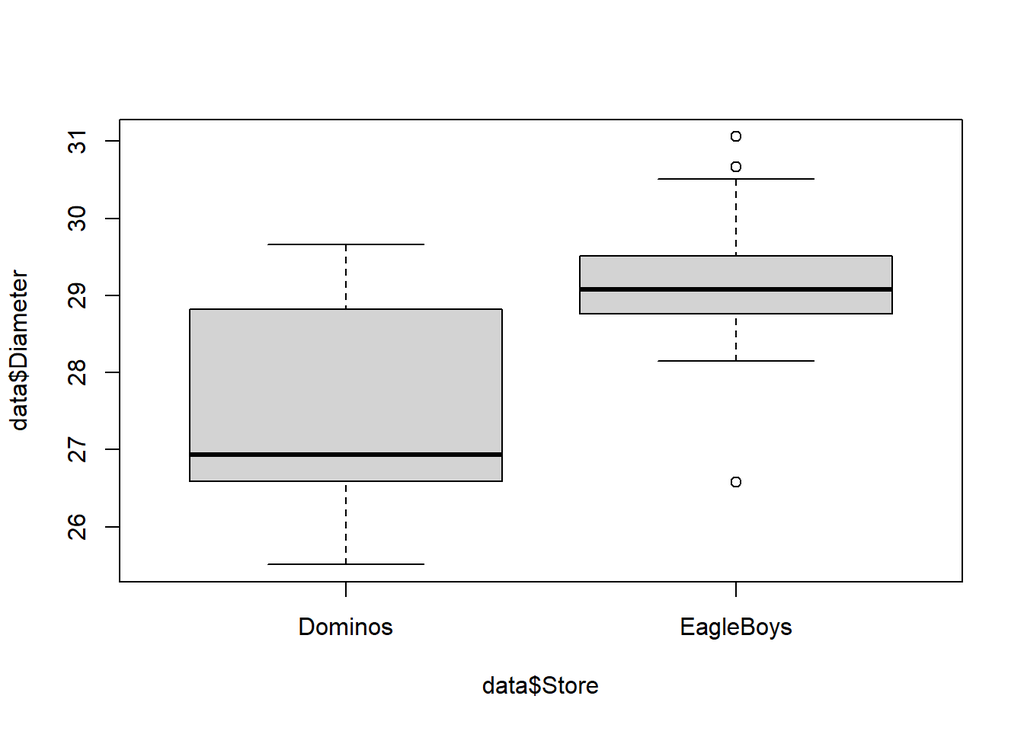

## Testes de Hipóteses: Exemplos Práticos

### Teste t para Amostras Independentes

Primeiro, verificamos as suposições de normalidade e homogeneidade das variâncias.

```
##
##  Shapiro-Wilk normality test
##
## data:  data$Diameter[data$Store == "Dominos"]
## W = 0.84692, p-value = 4.759e-10
```

**Interpretação:** Como valor retornado é **p-value = 4.759e-10**, menor que **0.05**, **rejeitamos** a hipótese que o diâmetro das pizzas da loja Dominos segue uma distribuição normal.

```
##
##  Shapiro-Wilk normality test
##
## data:  data$Diameter[data$Store == "EagleBoys"]
## W = 0.96291, p-value = 0.001673
```

**Interpretação:** Como valor retornado é **p-value = 0.001673**, menor que **0.05**, **rejeitamos** a hipótese que o diâmetro das pizzas da loja EagleBoys segue uma distribuição normal.

```
## Levene's Test for Homogeneity of Variance (center = median)
##        Df F value    Pr(>F)
## group   1  28.082 2.568e-07 ***
##       248
## ---
## Signif. codes:  0 '***' 0.001 '**' 0.01 '*' 0.05 '.' 0.1 ' ' 1
```

**Interpretação:** Como o **p-valor = 2.568e-07** é menor que **0.05**, concluímos que **as variâncias dos grupos não são homogêneas**.

Como as suposições **não** foram atendidas, não podemos aplicar o t.test para a hipótese em questão

```r
t.test(Diameter ~ Store, data = data, alternative = "greater")
```

## Estudo de Caso: Análise das Pizzas

### Contexto

A Eagle Boys, uma rede de pizzarias australiana, afirma que suas pizzas grandes são maiores que as da Dominos. Para testar essa afirmação, coletamos dados sobre os diâmetros das pizzas de ambas as redes.

### Preparação dos Dados

A preparação dos dados inclui padronização dos tipos de massa e sabores das pizzas para garantir comparabilidade justa.

[output not shown]

## Conclusão

Este artigo apresentou uma visão abrangente sobre testes de hipóteses, destacando tanto os aspectos teóricos quanto práticos, com ênfase na implementação em R. Utilizamos um estudo de caso real para consolidar o entendimento, demonstrando como preparar os dados, realizar análises descritivas e aplicar testes de hipóteses para tomar decisões informadas.

## Referências

- Bussab, W.D.O., & Morretin, P.A. (2013). Estatística Básica. São Paulo: Saraiva.
- Aula de Estatística Básica e Introdução ao R, Profª. Dra. Natalia Giordani.
- Montgomery, D.C., & Runger, G.C. (2014). Applied Statistics and Probability for Engineers. John Wiley & Sons.
- Field, A. (2013). Discovering Statistics Using R. Sage Publications.